# Creating maps in R

CMSC 205, Winter 2017

March 5, 2017

## Toolkit

```r
library(tidyverse) # all of our usual tools
library(ggmap)     # for spatial viz.
library(viridis)   # for color scales
```

## Oklahoma earthquakes

- The number of earthquakes in Oklahoma has increased in the past decade
- We will examine data obtained from the U.S. Geological Survey (USGS) on earthquakes in Oklahoma since 2000

```r
ok_quakes <- read.csv("https://raw.githubusercontent.com/cmsc205/notes/master/day20/OKquakes.csv")
str(ok_quakes)
```

```
'data.frame':   5204 obs. of  9 variables:
 $ time     : Factor w/ 5204 levels "2000-10-08T10:16:23.780Z",..: 5204 5203 5202 5201 5200 5199 5198 5197 5196 5195 ...
 $ latitude : num  35.8 36.6 35.7 36.8 35.7 ...
 $ longitude: num  -97.6 -98.8 -97.4 -97.8 -97.4 ...
 $ depth    : num  6.48 6.29 5.97 5.41 6.18 ...
 $ mag      : num  2.6 3.2 2.5 3 2.8 2.5 3 3.2 3.1 3.3 ...
 $ place    : Factor w/ 1433 levels "0km E of Pawnee, Oklahoma",..: 466 840 1177 1069 1236 318 1236 1092 1242 90 ...
 $ year     : int  2015 2015 2015 2015 2015 2015 2015 2015 2015 2015 ...
 $ month    : int  12 12 12 12 12 12 12 12 12 12 ...
 $ type     : Factor w/ 4 levels "light","minor",..: 4 2 4 2 4 4 2 2 2 2 ...
```

## Displaying spatial data with `ggplot2`

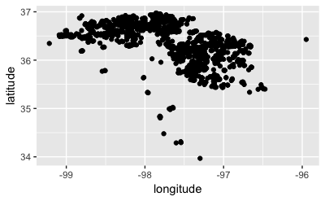

```r
ggplot(data = filter(ok_quakes, year == 2015), aes(x = longitude, y = latitude)) +
  geom_point()
```

## The `ggmap` package

- Context is important, we need more than just the points!
- `ggmap` allows us to grab this context from Google or other sources
- By default, `get_map`, downloads a terrain image from Google maps

[figure not shown]

```r
# Download the requested map
ok_map <- get_map(location = 'oklahoma', zoom = 7)
# Display the map
ggmap(ok_map)
```

1. Look at the help file for `get_map` and read about the `location` and `zoom` arguments. Do the following:
- Use `location = 'lawrence university'` to get a map of the surrounding area. Try difference values for `zoom`.
- Choose a city and use [Google maps](https://www.google.com/maps) to find the longitude and latitude of a landmark. Specify the coordinates in the `location` argument and produce a map of the surrounding area. Again, try different values for `zoom`.

There are other options aside from a terrain map.

2. Look at the help file for the `get_map` function and read about the `maptype` and `source` arguments. Specify different `maptypes` and `sources`. How do things change?

Now that we have our map of Oklahoma, we can add points to it:

[figure not shown]

```r
ggmap(ok_map) +
  geom_point(data = ok_quakes, aes(x = longitude, y = latitude, color = year))
```

A better idea might be to facet the plot by year. In order to to this we need to add the `base_layer` argument to the `ggmap` function:

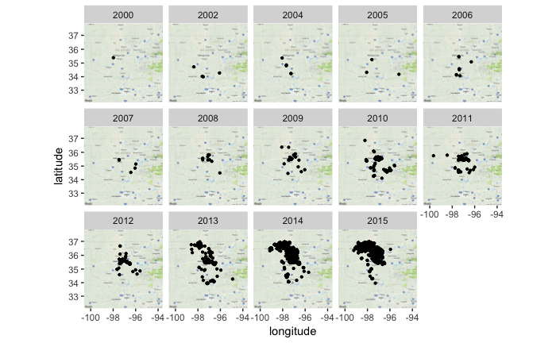

```r
ggmap(ok_map, base_layer = ggplot(ok_quakes, aes(x = longitude, y = latitude))) +
  geom_point(size = .8) +
  facet_wrap(~year, ncol = 5)
```

3. Add color to the faceted map based on the `type` of earthquake. Be sure to use an appropriate color palette. Do any patterns emerge?
4. The file [`CAquakes.csv`](https://raw.githubusercontent.com/cmsc205/notes/master/day20/CAquakes.csv) contains data on earthquakes in California from January 1, 2010 through the end of 2015. Use `ggmap` to plot the earthquakes that occurred in California during this time, similar to what we did for Oklahoma above. Do any patterns emerge?

## Heatmaps

```r
ok2015 <- filter(ok_quakes, year == 2015)
```

We can create heat maps using `stat_density2d` in place of our `geom_point` layer:

[figure not shown]

```r
ggmap(ok_map, base_layer = ggplot(ok2015, aes(x = longitude, y = latitude))) +
  stat_density2d(aes(fill = ..level.., alpha = ..level..), size = 0.01,
    bins = 16, geom = "polygon") +
  scale_fill_viridis() +
  scale_alpha(guide = FALSE)
```

5. Create a heat map of California earthquakes in 2015.